#### Selecting Models Based on the Lowest Forecast RMSE

#### 1. Analyize Series’ First 80% Training Set

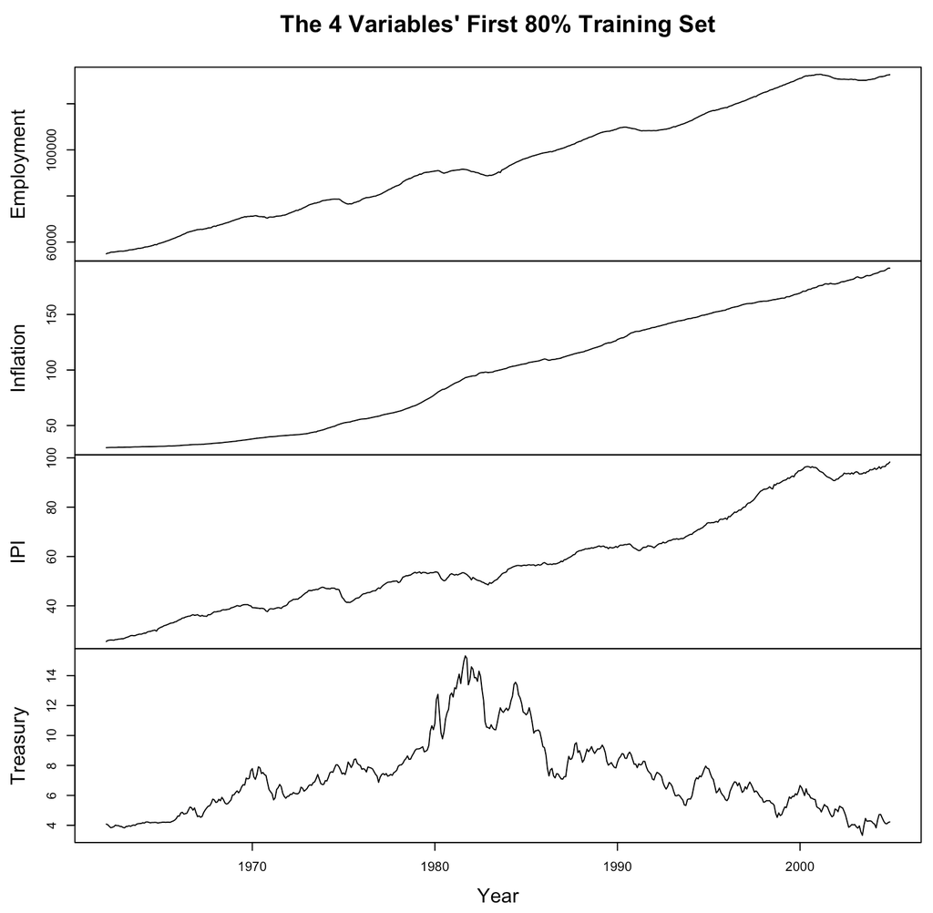

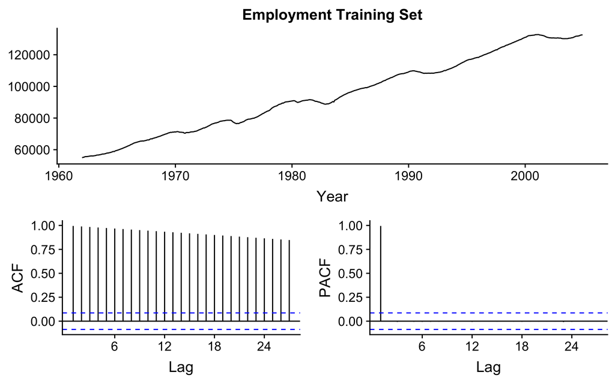

Employment Training Set doesn’t pass the ADF test or the Ljung-Box test up to 24 lags. The correlogram suggests an AR(1) effect.

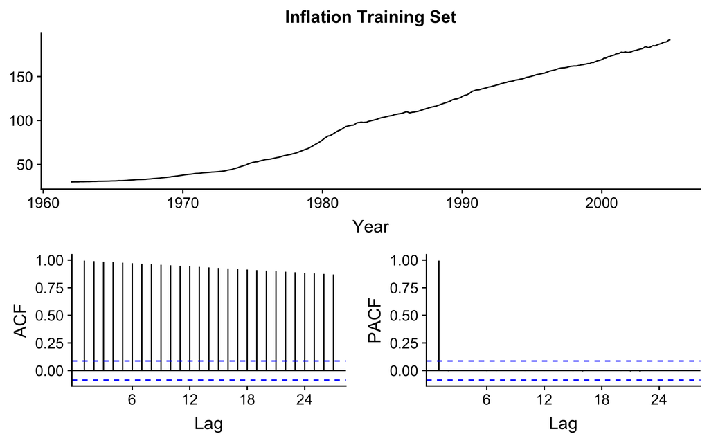

Inflation Training Set doesn’t pass the ADF test or the Ljung-Box test up to 24 lags. The correlogram suggests an AR(1) effect.

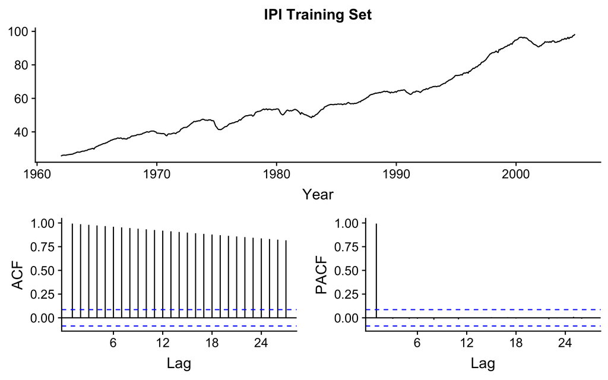

IPI Training Set doesn’t pass the ADF test or the Ljung-Box test up to 24 lags. The correlogram suggests an AR(1) effect.

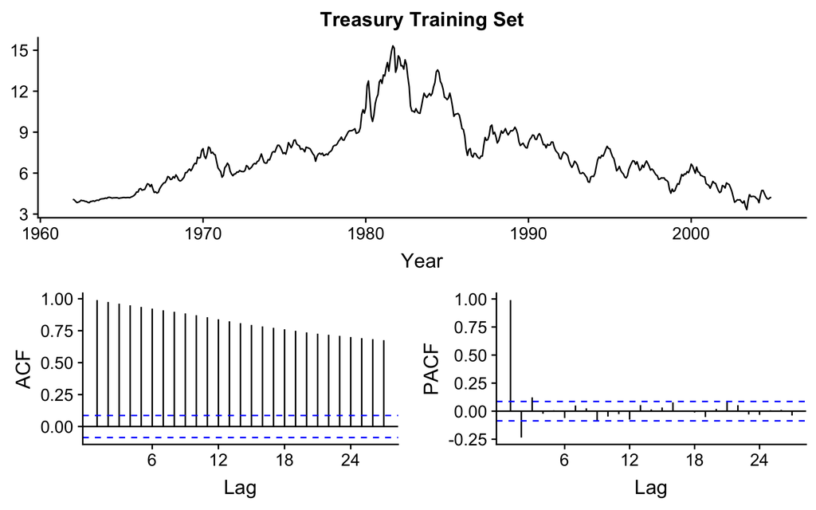

Treasury Rate Training Set doesn’t pass the ADF test or the Ljung-Box test up to 24 lags. The correlogram suggests an AR(2) or AR(3) effect.

#### 2. Compare the Forecast RMSEs from Various Model Structures with Various Lags.

Forecast RMSEs when Employment and Inflation as endogenous variables, without any exogenous variables

```
RMSE           Lag1     Lag2     Lag3     Lag4     Lag5     Lag6     Lag7
Employment 7999.700 9776.560 10988.48 11537.58 11725.73 11873.34 11978.09
Inflation     3.230    3.340     3.27     3.22     3.18     3.17     3.14
Sum        8002.925 9779.899 10991.76 11540.80 11728.91 11876.51 11981.22
               Lag8     Lag9
Employment 12008.04 12057.13
Inflation      3.07     2.91
Sum        12011.11 12060.04
```

Forecast RMSEs when Employment and Inflation as endogenous variables, IPI as exogenous variables

```
RMSE           Lag1     Lag2    Lag3     Lag4     Lag5     Lag6     Lag7
Employment 9677.530 10442.44 10867.3 11118.70 11258.04 11358.06 11457.50
Inflation     5.400     5.08     4.8     4.55     4.45     4.40     4.21
Sum        9682.931 10447.51 10872.1 11123.26 11262.50 11362.45 11461.70
               Lag8     Lag9
Employment 11508.04 11485.78
Inflation      4.00     3.38
Sum        11512.04 11489.16
```

Forecast RMSEs when Employment and Inflation as endogenous variables, Treasury as exogenous variables

```
RMSE           Lag1     Lag2     Lag3     Lag4     Lag5     Lag6     Lag7
Employment 10720.17 12081.78 12910.53 13153.69 13097.35 13082.17 13038.82
Inflation      9.58     8.01     6.82     6.09     5.89     5.92     5.80
Sum        10729.75 12089.79 12917.35 13159.79 13103.23 13088.09 13044.62
               Lag8     Lag9
Employment 12984.25 13099.97
Inflation      5.64     4.73
Sum        12989.89 13104.70
```

Forecast RMSEs when Employment and Inflation as endogenous variables, IPI and Treasury as exogenous variables

```
RMSE           Lag1     Lag2     Lag3     Lag4     Lag5     Lag6     Lag7
Employment 10295.64 11135.35 11781.72 12038.03 12111.73 12139.07 12170.85
Inflation      9.07     7.81     6.87     6.30     6.13     6.19     6.13
Sum        10304.71 11143.16 11788.59 12044.33 12117.86 12145.27 12176.98
               Lag8     Lag9
Employment 12167.25 12178.73
Inflation      5.98     5.23
Sum        12173.23 12183.96
```

Forecast RMSEs when all four variables as endogenous variables

```
RMSE           Lag1     Lag2     Lag3     Lag4     Lag5     Lag6     Lag7
Employment 11595.51 11961.06 11986.23 12059.39 11950.03 12396.75 12168.55
Inflation     14.49    16.48    14.51    12.24    11.09     9.73     7.91
Sum        11610.00 11977.53 12000.74 12071.63 11961.12 12406.48 12176.46
               Lag8     Lag9
Employment 12406.15 12346.63
Inflation      7.10     7.30
Sum        12413.25 12353.93
```

#### 3. The Model with the Lowest Forecast RMSE

The lowest forecast RMSE happens when Employment and Inflation as endogenous variables, without any exogenous variables, and the lag=1.

```
RMSE           Lag1
Employment 7999.700
Inflation     3.230
Sum        8002.925
```

Next, I can improve my models based on the new ideas from my classmates and add residuals analyses when comparing models.

rmarkdown::render(“U5P1.rmd”)